# Hospital Quality Project

## Introduction

In this project I work with dataset from The [Hosptial Compare web site](http://hospitalcompare.hhs.gov/) run by the U.S. Department of Health and Human Services. The web site provide data and information about the quality of care at over 4,000 Medicare-certied hospitals in the U.S.

For this project we use only a subset of data which the web site contains.

There are three files:

- **outcome-of-care-measures.csv**: Contains information about 30-day mortality and readmission rates for heart attacks, heart failure, and pneumonia for over 4,000 hospitals.
- **hospital-data.csv**: Contains information about each hospital.
- **Hospital_Revised_Flatfiles.pdf**: Descriptions of the variables in each file (i.e the code book).

### what we are going to do in this assignment:

1- Plot the 30-day mortality rates for heart attack

2- Finding the best hospital in a state

3- Ranking hospitals by outcome in a state

4- Ranking hospitals in all states

## ————————————————————————————————-

## 1-Histogram for the 30-day mortality rates for heart attack

In this step I read the data from outcome-of-care-measures.csv ,then plot a histogram for column(11) which is contain the data for the 30-day mortality rates for heart attack.

```r
data <- read.csv("outcome-of-care-measures.csv", colClasses = "character")
data[,11] <- as.numeric(data[, 11])
```

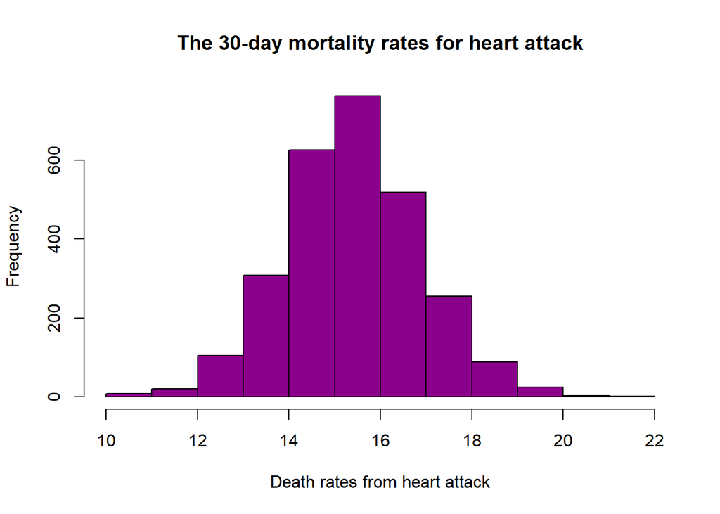

```r
outcome_data <- data[, 11]
hist(outcome_data, main = "The 30-day mortality rates for heart attack",
     xlab="Death rates from heart attack",
     col = "darkmagenta")
```

## ————————————————————————————————

## 2-Function returns the best hospital in a state

A function called “best” that take two arguments: the 2-character abbreviated name of a state and an outcome name. The function reads the outcome-of-care-measures.csv file and returns a character vector with the name of the hospital that has the best (lowest) 30-day mortality for the specified outcome in that state.

**Note:** The outcomes can be one of “heart attack”, “heart failure”, or “pneumonia”.

### Implementation:

```r
best <- function(state, outcome)
{
  data <- read.csv("outcome-of-care-measures.csv", colClasses = "character")

  #First check outcome if is valid
  expected_outcome <- c("heart attack", "heart failure", "pneumonia")
  check_outcome <- outcome %in% expected_outcome
  if (check_outcome == FALSE )
  {
    stop("invalid outcome")
  }
  #check state if is valid
  check_state <- state %in% data$State
  if (check_state == FALSE )
  {
    stop("invalid state")
  }


  #change columns names
  data <- data[c(2, 7, 11, 17, 23)]
  names(data)[1] <- "name"
  names(data)[3] <- "heart attack"
  names(data)[4] <- "heart failure"
  names(data)[5] <- "pneumonia"

  data <- data[data$State == state & data[outcome] != "Not Available",]
  outcome_data <- data[, outcome]  #Read the outcome data



  #Return the best hospital
  index <- which.min(outcome_data)  #return index of the minmum value
  return(data[index, ]$name)
}
```

**Test cases:**

```r
best("TX", "heart attack")
```

```
## [1] "CYPRESS FAIRBANKS MEDICAL CENTER"
```

```r
best("TX", "heart failure")
```

```
## [1] "FORT DUNCAN MEDICAL CENTER"
```

```r
best("BB", "heart attack")
```

```
## Error in best("BB", "heart attack"): invalid state
```

```r
best("NY", "hert attack")
```

```
## Error in best("NY", "hert attack"): invalid outcome
```

## ————————————————————————————————

## 3-Function ranking hospitals by outcome in a state

A function called rankhospital that takes three arguments: the 2-character abbreviated name of a state (state), an outcome (outcome), and the ranking of a hospital in that state for that outcome (num).

The function returns a character vector with the name of the hospital that has the ranking specified by the num argument.

### Implementation:

```r
rankhospital <- function(state, outcome, num = "best")
{

  data <- read.csv("outcome-of-care-measures.csv", colClasses = "character")

  #First check outcome if is valid
  expected_outcome <- c("heart attack", "heart failure", "pneumonia")
  check_outcome <- outcome %in% expected_outcome
  if (check_outcome == FALSE )
  {
    stop("invalid outcome")
  }
  #check state if is valid
  check_state <- state %in% data$State
  if (check_state == FALSE )
  {
    stop("invalid state")
  }


  #change columns names
  data <- data[c(2, 7, 11, 17, 23)]
  names(data)[1] <- "name"
  names(data)[3] <- "heart attack"
  names(data)[4] <- "heart failure"
  names(data)[5] <- "pneumonia"

  data <- data[data$State == state & data[outcome] != "Not Available",]

  #Ranking
  data[outcome] <- as.data.frame(sapply(data[outcome], as.numeric))
  data <- data[order(data$name, data[outcome] ,decreasing = FALSE), ]

  outcome_data <- data[, outcome]  #Read the outcome data

  if( num == "best" ) {
    index <- which.min(outcome_data)
  } else if( num == "worst" ) {
    index <- which.max(outcome_data)
  } else {
    index <- num
  }

  return(data[index, ]$name)

}
```

**Test cases:**

```r
rankhospital("TX", "heart failure", 4)
```

```
## [1] "ATLANTA MEMORIAL HOSPITAL"
```

```r
rankhospital("MD", "heart attack", "worst")
```

```
## [1] "HARFORD MEMORIAL HOSPITAL"
```

```r
rankhospital("MN", "heart attack", 5000)
```

```
## [1] NA
```

## ————————————————————————————————

## 4-Function ranking hospitals in all states

A function called rankall that takes two arguments: an outcome name (outcome) and a hospital ranking (num), returns a 2-column data frame containing the hospital in each state that has the ranking specified in num.

### Implementation

```r
rankall <- function(outcome, num = "best")
{
  data <- read.csv("outcome-of-care-measures.csv", colClasses = "character")

  #First check outcome if is valid
  expected_outcome <- c("heart attack", "heart failure", "pneumonia")
  check_outcome <- outcome %in% expected_outcome
  if (check_outcome == FALSE )
  {
    stop("invalid outcome")
  }

  #change columns names
  data <- data[c(2, 7, 11, 17, 23)]
  names(data)[1] <- "name"
  names(data)[2] <- "state"
  names(data)[3] <- "heart attack"
  names(data)[4] <- "heart failure"
  names(data)[5] <- "pneumonia"

  data <- data[data[outcome] != "Not Available",]

  data[outcome] <- as.data.frame(sapply(data[outcome], as.numeric))
  data <- data[order(data$name, data[outcome] ,decreasing = FALSE), ]

  #Helper Function
  hospital_rank <- function(df, s, n)
  {
    df <- df[df$state==s, ]
    outcome_data <- df[,outcome]
    if( n == "best" ) {
      index <- which.min(outcome_data)
    }else if( n == "worst" ) {
      index <- which.max(outcome_data)
    }else {
      index <- n
    }
    df[index, ]$name
  }

  ## For each state, find the hospital of the given rank
  states <- data[, 2]
  states <- unique(states)
  ranking_data <- data.frame(hospital = c(), state = c())
  for(st in states) {
    hosp <- hospital_rank(data, st, num)
    ranking_data <- rbind(ranking_data, data.frame(hospital = hosp, state = st))
  }

  ## Return a data frame(arranged) with hospital name and state name
  ranking_data <- ranking_data[order(ranking_data['state'], decreasing = FALSE), ]
  return(ranking_data)

}
```

**Test cases:**

```r
head(rankall("heart attack", 20), 10)
```

```
##                                  hospital state
## 12                                   <NA>    AK
## 27                 FAYETTE MEDICAL CENTER    AL
## 23 NORTH ARKANSAS REGIONAL MEDICAL CENTER    AR
## 22    JOHN C LINCOLN DEER VALLEY HOSPITAL    AZ
## 8       CENTINELA HOSPITAL MEDICAL CENTER    CA
## 24          NORTH COLORADO MEDICAL CENTER    CO
## 42             ROCKVILLE GENERAL HOSPITAL    CT
## 51                                   <NA>    DC
## 38                                   <NA>    DE
## 34                CAPE CANAVERAL HOSPITAL    FL
```

```r
tail(rankall("pneumonia", "worst"), 3)
```

```
##                                      hospital state
## 23 MAYO CLINIC HEALTH SYSTEM - NORTHLAND, INC    WI
## 46                     PLATEAU MEDICAL CENTER    WV
## 49           NORTH BIG HORN HOSPITAL DISTRICT    WY
```

```r
tail(rankall("heart failure"), 10)
```

```
##                                                             hospital state
## 34                         WELLMONT HAWKINS COUNTY MEMORIAL HOSPITAL    TN
## 4                                         FORT DUNCAN MEDICAL CENTER    TX
## 19 VA SALT LAKE CITY HEALTHCARE - GEORGE E. WAHLEN VA MEDICAL CENTER    UT
## 38                                          SENTARA POTOMAC HOSPITAL    VA
## 52                            GOV JUAN F LUIS HOSPITAL & MEDICAL CTR    VI
## 47                                              SPRINGFIELD HOSPITAL    VT
## 36                                         HARBORVIEW MEDICAL CENTER    WA
## 22                                    AURORA ST LUKES MEDICAL CENTER    WI
## 46                                         FAIRMONT GENERAL HOSPITAL    WV
## 49                                        CHEYENNE VA MEDICAL CENTER    WY
```